# Predicting Exercise Correctness by Accelerometer Device

J.E. Turcotte

June 11, 2016

## Executive Summary

Six young health participants were asked to perform one set of 10 repetitions of the Unilateral Dumbbell Biceps Curl in five different fashions: exactly according to the specification (Class A), throwing the elbows to the front (Class B), lifting the dumbbell only halfway (Class C), lowering the dumbbell only halfway (Class D) and throwing the hips to the front (Class E). In this brief study, we try a few different classification regressions to arrive at a very high accuracy prediction model capable of assessing future data sets for this particularly kind of exercise.

## Assumptions

This predictive model assumes that…

- We do not need to know the individual who is doing the exercise, insofar as doing an exercise correctly or incorrectly in a number of predictable ways is common to all people.
- It might be of interest to treat each variable as a time sequence, given the timestamps available, but that we should still be able to predict future movement classes without this.

## Data Examination and Repair

Given the large number of variables available, a quick look through **Fig.1** – *a table of variation and uniqueness within the training data set* – suggests that we can afford to cull quite a few. In **Fig.2** we see all that remain after selecting out the union of *9* zero variation variables, *100* variables that are more than 90 ‘na’, and *7*, like *user_name* against which we specifically do NOT want to predict, or are otherwise not important and might confuse our results if left intact.

## Partitioning of Training and Test Data

For the purposes of this predictive model production, we will be splitting our initial training data two ways. *17662* remain in the training set while *1960* will become our final in-study test.

## Examining Possible Models

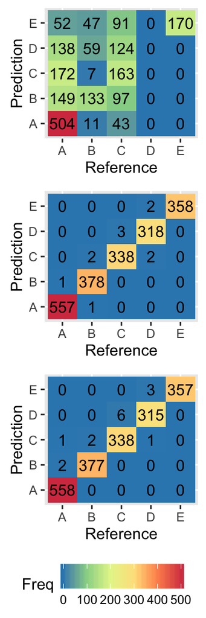

Note that, in both of the following cases, we’ve already effectively disqualified a large number of potential predictors, so we begin (and find that we can end) with the most basic of model formalae.

## Concluding with a Simpler Model

As you can see in the bototm of the right-hand plots, the net result, clocks in with a barely touched accuracy of *99.23%*, and the following *9* predictors were enough to provide a very very accuracte prediction model:

*accel_belt_z*, *magnet_belt_y*, *magnet_dumbbell_y*, *magnet_dumbbell_z*, *pitch_forearm*, *roll_belt*, *roll_forearm*, *total_accel_belt* and *yaw_belt*

## Source

Ugulino, W.; Cardador, D.; Vega, K.; Velloso, E.; Milidiu, R.; Fuks, H. Wearable Computing: Accelerometers’ Data Classification of Body Postures and Movements. Proceedings of 21st Brazilian Symposium on Artificial Intelligence. Advances in Artificial Intelligence - SBIA 2012. In: Lecture Notes in Computer Science. , pp. 52-61. Curitiba, PR: Springer Berlin / Heidelberg, 2012. ISBN 978-3-642-34458-9. DOI: 10.1007/978-3-642-34459-6_6. Cited by 2 (Google Scholar)

Read more: http://groupware.les.inf.puc-rio.br/har#ixzz4Bz9LVKWs

## Appendices

#### Fig.1; Near Zero Variation

|  | freqRatio | percentUnique | zeroVar | nzv |
| --- | --- | --- | --- | --- |
| **roll_belt** | 1.102 | 6.778 | FALSE | FALSE |
| **pitch_belt** | 1.036 | 9.377 | FALSE | FALSE |
| **yaw_belt** | 1.058 | 9.973 | FALSE | FALSE |
| **total_accel_belt** | 1.063 | 0.1478 | FALSE | FALSE |
| **gyros_belt_x** | 1.059 | 0.7135 | FALSE | FALSE |
| **gyros_belt_y** | 1.144 | 0.3516 | FALSE | FALSE |
| **gyros_belt_z** | 1.066 | 0.8613 | FALSE | FALSE |
| **accel_belt_x** | 1.055 | 0.8358 | FALSE | FALSE |
| **accel_belt_y** | 1.114 | 0.7288 | FALSE | FALSE |
| **accel_belt_z** | 1.079 | 1.524 | FALSE | FALSE |
| **magnet_belt_x** | 1.09 | 1.666 | FALSE | FALSE |
| **magnet_belt_y** | 1.1 | 1.519 | FALSE | FALSE |
| **magnet_belt_z** | 1.006 | 2.329 | FALSE | FALSE |
| **roll_arm** | 52.34 | 13.53 | FALSE | FALSE |
| **pitch_arm** | 87.26 | 15.73 | FALSE | FALSE |
| **yaw_arm** | 33.03 | 14.66 | FALSE | FALSE |
| **total_accel_arm** | 1.025 | 0.3364 | FALSE | FALSE |
| **gyros_arm_x** | 1.016 | 3.277 | FALSE | FALSE |
| **gyros_arm_y** | 1.454 | 1.916 | FALSE | FALSE |
| **gyros_arm_z** | 1.111 | 1.264 | FALSE | FALSE |
| **accel_arm_x** | 1.017 | 3.96 | FALSE | FALSE |
| **accel_arm_y** | 1.14 | 2.737 | FALSE | FALSE |
| **accel_arm_z** | 1.128 | 4.036 | FALSE | FALSE |
| **magnet_arm_x** | 1 | 6.824 | FALSE | FALSE |
| **magnet_arm_y** | 1.057 | 4.444 | FALSE | FALSE |
| **magnet_arm_z** | 1.036 | 6.447 | FALSE | FALSE |
| **roll_dumbbell** | 1.022 | 84.21 | FALSE | FALSE |
| **pitch_dumbbell** | 2.277 | 81.74 | FALSE | FALSE |
| **yaw_dumbbell** | 1.132 | 83.48 | FALSE | FALSE |
| **total_accel_dumbbell** | 1.073 | 0.2191 | FALSE | FALSE |
| **gyros_dumbbell_x** | 1.003 | 1.228 | FALSE | FALSE |
| **gyros_dumbbell_y** | 1.265 | 1.417 | FALSE | FALSE |
| **gyros_dumbbell_z** | 1.06 | 1.05 | FALSE | FALSE |
| **accel_dumbbell_x** | 1.018 | 2.166 | FALSE | FALSE |
| **accel_dumbbell_y** | 1.053 | 2.375 | FALSE | FALSE |
| **accel_dumbbell_z** | 1.133 | 2.089 | FALSE | FALSE |
| **magnet_dumbbell_x** | 1.098 | 5.749 | FALSE | FALSE |
| **magnet_dumbbell_y** | 1.198 | 4.301 | FALSE | FALSE |
| **magnet_dumbbell_z** | 1.021 | 3.445 | FALSE | FALSE |
| **roll_forearm** | 11.59 | 11.09 | FALSE | FALSE |
| **pitch_forearm** | 65.98 | 14.86 | FALSE | FALSE |
| **yaw_forearm** | 15.32 | 10.15 | FALSE | FALSE |
| **total_accel_forearm** | 1.129 | 0.3567 | FALSE | FALSE |
| **gyros_forearm_x** | 1.059 | 1.519 | FALSE | FALSE |
| **gyros_forearm_y** | 1.037 | 3.776 | FALSE | FALSE |
| **gyros_forearm_z** | 1.123 | 1.565 | FALSE | FALSE |
| **accel_forearm_x** | 1.126 | 4.046 | FALSE | FALSE |
| **accel_forearm_y** | 1.059 | 5.112 | FALSE | FALSE |
| **accel_forearm_z** | 1.006 | 2.956 | FALSE | FALSE |
| **magnet_forearm_x** | 1.012 | 7.767 | FALSE | FALSE |
| **magnet_forearm_y** | 1.247 | 9.54 | FALSE | FALSE |
| **magnet_forearm_z** | 1 | 8.577 | FALSE | FALSE |
| **classe** | 1.47 | 0.02548 | FALSE | FALSE |

#### Fig.2; After Culling Needless Variables

After studying the nature of the variables a few times, this study has whittled down those that will be considered for the prediction model down to the following.

Table continues below

| roll_belt | pitch_belt | yaw_belt | total_accel_belt |
| --- | --- | --- | --- |
| Min. :-28.90 | Min. :-55.8000 | Min. :-180.00 | Min. : 0.00 |
| 1st Qu.: 1.10 | 1st Qu.: 1.7600 | 1st Qu.: -88.30 | 1st Qu.: 3.00 |
| Median :113.00 | Median : 5.2800 | Median : -13.00 | Median :17.00 |
| Mean : 64.41 | Mean : 0.3053 | Mean : -11.21 | Mean :11.31 |
| 3rd Qu.:123.00 | 3rd Qu.: 14.9000 | 3rd Qu.: 12.90 | 3rd Qu.:18.00 |
| Max. :162.00 | Max. : 60.3000 | Max. : 179.00 | Max. :29.00 |

Table continues below

| gyros_belt_x | gyros_belt_y | gyros_belt_z | accel_belt_x |
| --- | --- | --- | --- |
| Min. :-1.040000 | Min. :-0.64000 | Min. :-1.4600 | Min. :-120.000 |
| 1st Qu.:-0.030000 | 1st Qu.: 0.00000 | 1st Qu.:-0.2000 | 1st Qu.: -21.000 |
| Median : 0.030000 | Median : 0.02000 | Median :-0.1000 | Median : -15.000 |
| Mean :-0.005592 | Mean : 0.03959 | Mean :-0.1305 | Mean : -5.595 |
| 3rd Qu.: 0.110000 | 3rd Qu.: 0.11000 | 3rd Qu.:-0.0200 | 3rd Qu.: -5.000 |
| Max. : 2.220000 | Max. : 0.64000 | Max. : 1.6200 | Max. : 85.000 |

Table continues below

| accel_belt_y | accel_belt_z | magnet_belt_x | magnet_belt_y | magnet_belt_z |
| --- | --- | --- | --- | --- |
| Min. :-69.00 | Min. :-275.00 | Min. :-52.0 | Min. :354.0 | Min. :-623.0 |
| 1st Qu.: 3.00 | 1st Qu.:-162.00 | 1st Qu.: 9.0 | 1st Qu.:581.0 | 1st Qu.:-375.0 |
| Median : 35.00 | Median :-152.00 | Median : 35.0 | Median :601.0 | Median :-320.0 |
| Mean : 30.15 | Mean : -72.59 | Mean : 55.6 | Mean :593.7 | Mean :-345.5 |
| 3rd Qu.: 61.00 | 3rd Qu.: 27.00 | 3rd Qu.: 59.0 | 3rd Qu.:610.0 | 3rd Qu.:-306.0 |
| Max. :164.00 | Max. : 105.00 | Max. :485.0 | Max. :673.0 | Max. : 293.0 |

Table continues below

| roll_arm | pitch_arm | yaw_arm | total_accel_arm |
| --- | --- | --- | --- |
| Min. :-180.00 | Min. :-88.800 | Min. :-180.0000 | Min. : 1.00 |
| 1st Qu.: -31.77 | 1st Qu.:-25.900 | 1st Qu.: -43.1000 | 1st Qu.:17.00 |
| Median : 0.00 | Median : 0.000 | Median : 0.0000 | Median :27.00 |
| Mean : 17.83 | Mean : -4.612 | Mean : -0.6188 | Mean :25.51 |
| 3rd Qu.: 77.30 | 3rd Qu.: 11.200 | 3rd Qu.: 45.8750 | 3rd Qu.:33.00 |
| Max. : 180.00 | Max. : 88.500 | Max. : 180.0000 | Max. :66.00 |

Table continues below

| gyros_arm_x | gyros_arm_y | gyros_arm_z | accel_arm_x | accel_arm_y |
| --- | --- | --- | --- | --- |
| Min. :-6.37000 | Min. :-3.4400 | Min. :-2.3300 | Min. :-404.00 | Min. :-318.0 |
| 1st Qu.:-1.33000 | 1st Qu.:-0.8000 | 1st Qu.:-0.0700 | 1st Qu.:-242.00 | 1st Qu.: -54.0 |
| Median : 0.08000 | Median :-0.2400 | Median : 0.2300 | Median : -44.00 | Median : 14.0 |
| Mean : 0.04277 | Mean :-0.2571 | Mean : 0.2695 | Mean : -60.24 | Mean : 32.6 |
| 3rd Qu.: 1.57000 | 3rd Qu.: 0.1400 | 3rd Qu.: 0.7200 | 3rd Qu.: 84.00 | 3rd Qu.: 139.0 |
| Max. : 4.87000 | Max. : 2.8400 | Max. : 3.0200 | Max. : 437.00 | Max. : 308.0 |

Table continues below

| accel_arm_z | magnet_arm_x | magnet_arm_y | magnet_arm_z | roll_dumbbell |
| --- | --- | --- | --- | --- |
| Min. :-636.00 | Min. :-584.0 | Min. :-392.0 | Min. :-597.0 | Min. :-153.71 |
| 1st Qu.:-143.00 | 1st Qu.:-300.0 | 1st Qu.: -9.0 | 1st Qu.: 131.2 | 1st Qu.: -18.49 |
| Median : -47.00 | Median : 289.0 | Median : 202.0 | Median : 444.0 | Median : 48.17 |
| Mean : -71.25 | Mean : 191.7 | Mean : 156.6 | Mean : 306.5 | Mean : 23.84 |
| 3rd Qu.: 23.00 | 3rd Qu.: 637.0 | 3rd Qu.: 323.0 | 3rd Qu.: 545.0 | 3rd Qu.: 67.61 |
| Max. : 292.00 | Max. : 782.0 | Max. : 583.0 | Max. : 694.0 | Max. : 153.55 |

Table continues below

| pitch_dumbbell | yaw_dumbbell | total_accel_dumbbell | gyros_dumbbell_x |
| --- | --- | --- | --- |
| Min. :-149.59 | Min. :-150.871 | Min. : 0.00 | Min. :-204.0000 |
| 1st Qu.: -40.89 | 1st Qu.: -77.644 | 1st Qu.: 4.00 | 1st Qu.: -0.0300 |
| Median : -20.96 | Median : -3.324 | Median :10.00 | Median : 0.1300 |
| Mean : -10.78 | Mean : 1.674 | Mean :13.72 | Mean : 0.1611 |
| 3rd Qu.: 17.50 | 3rd Qu.: 79.643 | 3rd Qu.:19.00 | 3rd Qu.: 0.3500 |
| Max. : 149.40 | Max. : 154.952 | Max. :58.00 | Max. : 2.2200 |

Table continues below

| gyros_dumbbell_y | gyros_dumbbell_z | accel_dumbbell_x | accel_dumbbell_y |
| --- | --- | --- | --- |
| Min. :-2.10000 | Min. : -2.380 | Min. :-419.00 | Min. :-189.00 |
| 1st Qu.:-0.14000 | 1st Qu.: -0.310 | 1st Qu.: -50.00 | 1st Qu.: -8.00 |
| Median : 0.03000 | Median : -0.130 | Median : -8.00 | Median : 41.50 |
| Mean : 0.04606 | Mean : -0.129 | Mean : -28.62 | Mean : 52.63 |
| 3rd Qu.: 0.21000 | 3rd Qu.: 0.030 | 3rd Qu.: 11.00 | 3rd Qu.: 111.00 |
| Max. :52.00000 | Max. :317.000 | Max. : 235.00 | Max. : 315.00 |

Table continues below

| accel_dumbbell_z | magnet_dumbbell_x | magnet_dumbbell_y | magnet_dumbbell_z |
| --- | --- | --- | --- |
| Min. :-334.00 | Min. :-643.0 | Min. :-3600 | Min. :-262.00 |
| 1st Qu.:-142.00 | 1st Qu.:-535.0 | 1st Qu.: 231 | 1st Qu.: -45.00 |
| Median : -1.00 | Median :-479.0 | Median : 311 | Median : 13.00 |
| Mean : -38.32 | Mean :-328.5 | Mean : 221 | Mean : 46.05 |
| 3rd Qu.: 38.00 | 3rd Qu.:-304.0 | 3rd Qu.: 390 | 3rd Qu.: 95.00 |
| Max. : 318.00 | Max. : 592.0 | Max. : 633 | Max. : 452.00 |

Table continues below

| roll_forearm | pitch_forearm | yaw_forearm | total_accel_forearm |
| --- | --- | --- | --- |
| Min. :-180.0000 | Min. :-72.50 | Min. :-180.00 | Min. : 0.00 |
| 1st Qu.: -0.7375 | 1st Qu.: 0.00 | 1st Qu.: -68.60 | 1st Qu.: 29.00 |
| Median : 21.7000 | Median : 9.24 | Median : 0.00 | Median : 36.00 |
| Mean : 33.8265 | Mean : 10.71 | Mean : 19.21 | Mean : 34.72 |
| 3rd Qu.: 140.0000 | 3rd Qu.: 28.40 | 3rd Qu.: 110.00 | 3rd Qu.: 41.00 |
| Max. : 180.0000 | Max. : 89.80 | Max. : 180.00 | Max. :108.00 |

Table continues below

| gyros_forearm_x | gyros_forearm_y | gyros_forearm_z | accel_forearm_x |
| --- | --- | --- | --- |
| Min. :-22.000 | Min. : -7.02000 | Min. : -8.0900 | Min. :-498.00 |
| 1st Qu.: -0.220 | 1st Qu.: -1.46000 | 1st Qu.: -0.1800 | 1st Qu.:-178.00 |
| Median : 0.050 | Median : 0.03000 | Median : 0.0800 | Median : -57.00 |
| Mean : 0.158 | Mean : 0.07517 | Mean : 0.1512 | Mean : -61.65 |
| 3rd Qu.: 0.560 | 3rd Qu.: 1.62000 | 3rd Qu.: 0.4900 | 3rd Qu.: 76.00 |
| Max. : 3.970 | Max. :311.00000 | Max. :231.0000 | Max. : 477.00 |

Table continues below

| accel_forearm_y | accel_forearm_z | magnet_forearm_x | magnet_forearm_y |
| --- | --- | --- | --- |
| Min. :-632.0 | Min. :-446.00 | Min. :-1280.0 | Min. :-896.0 |
| 1st Qu.: 57.0 | 1st Qu.:-182.00 | 1st Qu.: -616.0 | 1st Qu.: 2.0 |
| Median : 201.0 | Median : -39.00 | Median : -378.0 | Median : 591.0 |
| Mean : 163.7 | Mean : -55.29 | Mean : -312.6 | Mean : 380.1 |
| 3rd Qu.: 312.0 | 3rd Qu.: 26.00 | 3rd Qu.: -73.0 | 3rd Qu.: 737.0 |
| Max. : 923.0 | Max. : 291.00 | Max. : 672.0 | Max. :1480.0 |

| magnet_forearm_z | classe |
| --- | --- |
| Min. :-973.0 | A:5580 |
| 1st Qu.: 191.0 | B:3797 |
| Median : 511.0 | C:3422 |
| Mean : 393.6 | D:3216 |
| 3rd Qu.: 653.0 | E:3607 |
| Max. :1090.0 | NA |

#### Fig.3; The Most Important Variables

- **importance**:

  |  | Overall |
  | --- | --- |
  | **accel_arm_x** | 26.17 |
  | **accel_belt_z** | 43.49 |
  | **accel_dumbbell_y** | 15.86 |
  | **magnet_arm_x** | 27.07 |
  | **magnet_belt_y** | 40.93 |
  | **magnet_dumbbell_y** | 49.45 |
  | **magnet_dumbbell_z** | 36.57 |
  | **pitch_forearm** | 100 |
  | **roll_arm** | 15.11 |
  | **roll_belt** | 70.26 |
  | **roll_dumbbell** | 18.92 |
  | **roll_forearm** | 74.83 |
  | **total_accel_belt** | 35.79 |
  | **yaw_belt** | 41.14 |
  | **pitch_belt** | 0 |
  | **gyros_belt_x** | 0 |
  | **gyros_belt_y** | 0 |
  | **gyros_belt_z** | 0 |
  | **accel_belt_x** | 0 |
  | **accel_belt_y** | 0 |
  | **magnet_belt_x** | 0 |
  | **magnet_belt_z** | 0 |
  | **pitch_arm** | 0 |
  | **yaw_arm** | 0 |
  | **total_accel_arm** | 0 |
  | **gyros_arm_x** | 0 |
  | **gyros_arm_y** | 0 |
  | **gyros_arm_z** | 0 |
  | **accel_arm_y** | 0 |
  | **accel_arm_z** | 0 |
  | **magnet_arm_y** | 0 |
  | **magnet_arm_z** | 0 |
  | **pitch_dumbbell** | 0 |
  | **yaw_dumbbell** | 0 |
  | **total_accel_dumbbell** | 0 |
  | **gyros_dumbbell_x** | 0 |
  | **gyros_dumbbell_y** | 0 |
  | **gyros_dumbbell_z** | 0 |
  | **accel_dumbbell_x** | 0 |
  | **accel_dumbbell_z** | 0 |
  | **magnet_dumbbell_x** | 0 |
  | **yaw_forearm** | 0 |
  | **total_accel_forearm** | 0 |
  | **gyros_forearm_x** | 0 |
  | **gyros_forearm_y** | 0 |
  | **gyros_forearm_z** | 0 |
  | **accel_forearm_x** | 0 |
  | **accel_forearm_y** | 0 |
  | **accel_forearm_z** | 0 |
  | **magnet_forearm_x** | 0 |
  | **magnet_forearm_y** | 0 |
  | **magnet_forearm_z** | 0 |

- **model**: rpart
- **calledFrom**: varImp